# Euler_sieve

Euler's sieve

Eric Martin, CSE, UNSW

COMP9021 Principles of Programming

```python
# Does not need to be executed if
# ~/.ipython/profile_default/ipython_config.py
# exists and contains:
# c.InteractiveShell.ast_node_interactivity = 'all'

from IPython.core.interactiveshell import InteractiveShell
InteractiveShell.ast_node_interactivity = 'all'
```

```python
import matplotlib_inline.backend_inline
matplotlib_inline.backend_inline.set_matplotlib_formats('retina')
```

```python
from random import randrange
from timeit import timeit
from itertools import zip_longest
import matplotlib.pyplot as plt
```

With Eratosthenes' sieve, a number can be ruled out more than once. For instance, in case $n\geq 12$, 12 will be ruled out as a multiple of 2 and then as a multiple of 3. Euler's sieve works with a list of numbers initialised as the list of all numbers between 2 and $n$ that, at a given stage, has lost those of its members that have been found out not to be prime, and that eventually has lost all of its nonprime numbers.

Let us try the following, to find out that there is a flaw.

- The first member of the list contains 2; multiplying 2 with 2 and the following members of the list up to and excluding the first number greater than $\lfloor\frac{n}{2}\rfloor$, should remove all proper multiples of 2 at most equal to $n$.
- The next member of the resulting list should contain 3; multiplying 3 with 3 and the following members of the list up to and excluding the first number greater than $\lfloor\frac{n}{3}\rfloor$, should remove all proper multiples of 3 at most equal to $n$ that remain, namely, those that are not multiple of 2.
- The next member of the resulting list should contain 5; multiplying 5 with 5 and the following members of the list up to and excluding the first number greater than $\lfloor\frac{n}{5}\rfloor$ should remove all proper multiples of 5 at most equal to $n$ that remain, namely, those that are not multiples of 2 or 3...
- ...

For illustration purposes, let us fix $n$ to some value, assign that value to a variable `n`, and define `sieve` accordingly:

```python
n = 25
sieve = list(range(2, n + 1))
```

```python
def print_sieve_contents():
    for p in sieve:
        print(f'{p:3}', end='')

print_sieve_contents()
```

```
  2  3  4  5  6  7  8  9 10 11 12 13 14 15 16 17 18 19 20 21 22 23 24 25
```

We are going to write code that makes use of **assignment expressions**, defined from the "walrus operator", namely, `:=`. Compare

```python
i = 2.1
j = i * i
while j <= n:
    print(j, end=' ')
    j *= i
```

```
4.41 9.261000000000001 19.448100000000004
```

or

```python
i = 2.1
j = i
while True:
    j *= i
    if j > n:
        break
    print(j, end=' ')
```

```
4.41 9.261000000000001 19.448100000000004
```

with

```python
i = 2.1
j = i
while (j := j * i) <= n:
    print(j, end=' ')
```

```
4.41 9.261000000000001 19.448100000000004
```

Now to observe how, with `n` set to `25`, proper multiples of 2 are removed, we call the following function with `i` set to `0` as argument:

```python
def eliminate_proper_multiples(i):
    print(f'Now eliminating proper multiples of {sieve[i]}')
    j = i
    while (factor := sieve[i] * sieve[j]) <= n:
            print(f' Eliminating {sieve[i]} * {sieve[j]} = {factor}')
            sieve.remove(factor)
            j += 1
```

```python
eliminate_proper_multiples(0)
print_sieve_contents()
```

```
Now eliminating proper multiples of 2
 Eliminating 2 * 2 = 4
 Eliminating 2 * 3 = 6
 Eliminating 2 * 5 = 10
 Eliminating 2 * 7 = 14
 Eliminating 2 * 8 = 16
 Eliminating 2 * 9 = 18
 Eliminating 2 * 11 = 22
 Eliminating 2 * 12 = 24
  2  3  5  7  8  9 11 12 13 15 17 19 20 21 23 25
```

We see the flaw. Having first eliminated $2\times 2$, 4 is no longer in the list, which prevents 8 from being eliminated, and the same holds for other multiples of 2.

This suggests to, for an arbitrary value of $n$, amend the procedure as follows.

- using 2, the first number in the list:
  - remove $2^2$, $2^3$, $2^4$, ..., up to $2^r$ for the largest $r$ with $2^r\leq n$,
  - remove $2\times 3$, $2^2\times 3$, $2^3\times 3$, ..., up to $2^r\times 3$ for the largest $r$ with $2^r\times 3\leq n$,
  - as 4 is no longer in the list, remove $2\times 5$, $2^2\times 5$, $2^3\times 5$, ..., up to $2^r\times 5$ for the largest $r$ with $2^r\times 5\leq n$,
  - as 6 is no longer in the list, remove $2\times 7$, $2^2\times 7$, $2^3\times 7$, ..., up to $2^r\times 7$ for the largest $r$ with $2^r\times 7\leq n$,
  - as 8 is no longer in the list, remove $2\times 9$, $2^2\times 9$, $2^3\times 9$, ..., up to $2^r\times 9$ for the largest $r$ with $2^r\times 9\leq n$,
  - ...
- using 3, the next number in what remains of the list:
  - remove $3^2$, $3^3$, $3^4$, ..., up to $3^r$ for the largest $r$ with $3^r\leq n$,
  - as 4 is no longer in the list, remove $3\times 5$, $3^2\times 5$, $3^3\times 5$, ..., up to $3^r\times 5$ for the largest $r$ with $3^r\times 5\leq n$,
  - as 6 is no longer in the list, remove $3\times 7$, $3^2\times 7$, $3^3\times 7$, ..., up to $3^r\times 7$ for the largest $r$ with $3^r\times 7\leq n$,
  - as 8, 9 and 10 are no longer in the list, remove $3\times 11$, $3^2\times 11$, $3^3\times 11$, ...., up to $3^r\times 11$ for the largest $r$ with $3^r\times 11\leq n$,
  - ...
- ...

We stop when the next number in what remains in the list exceeds $\lfloor\sqrt{n}\rfloor$.

Let us verify that the procedure is correct. At stage $k$, all proper multiples of the $k$th prime number $p_k$ at most equal to $n$ are removed from the list. This is verified by induction. Indeed, if during stage $k$, an integer $m>1$ with $p_k m\leq n$ is not considered then:

- either $m$ is smaller than $p_k$, in which case it is a multiple of at least one of $p_1$, ..., $p_{k-1}$, which implies that $p_k\times m$ is also a multiple of at least one of $p_1$, ..., $p_{k-1}$, so by inductive hypothesis, $p_k\times m$ was removed from the list during one of the previous stages,
- or $m$ is greater than $p_k$ but no longer belongs to the list (it is a number such as 4, 6, 8, ... at stage 1, or a number such as 4, 6, 8, 9, 10, ... at stage 2), in which case:
  - either $m$ was removed during one of the previous stages, hence $m$ is a multiple of at least one of $p_1$, ..., $p_{k-1}$, which implies as in the previous case that $p_k\times m$ was also removed from the list,
  - or $m$ is a multiple of $p_k$ which was removed earlier in the current stage, so $m$ is a number of the form $p_k^r m'$ for some $r\geq 1$ and some number $m'$ which was then found in what remained of the list, therefore $p_k m=p_k^{r+1}m'$ was also removed from the list earlier in the current stage.

```python
def eliminate_proper_multiples(i, k):
    # We assume that this function will be called in the order
    #   eliminate_proper_multiples(0, 0)
    #   eliminate_proper_multiples(0, 1)
    #   ...
    #   eliminate_proper_multiples(1, 0)
    #   eliminate_proper_multiples(1, 1)
    #   ...
    print(f'Now eliminating multiples of the form {sieve[i + k]} times '
          f'a power of {sieve[i]} greater than 1'
         )
    factor = sieve[i + k] * sieve[i]
    power = 1
    while factor <= n:
        print(f' Eliminating {sieve[i + k]} x {sieve[i]}^{power} = {factor}')
        sieve.remove(factor)
        factor *= sieve[i]
        power += 1
```

```python
sieve = list(range(2, n + 1))
print_sieve_contents()
```

```
  2  3  4  5  6  7  8  9 10 11 12 13 14 15 16 17 18 19 20 21 22 23 24 25
```

```python
eliminate_proper_multiples(0, 0)
print_sieve_contents()
```

```
Now eliminating multiples of the form 2 times a power of 2 greater than 1
 Eliminating 2 x 2^1 = 4
 Eliminating 2 x 2^2 = 8
 Eliminating 2 x 2^3 = 16
  2  3  5  6  7  9 10 11 12 13 14 15 17 18 19 20 21 22 23 24 25
```

```python
eliminate_proper_multiples(0, 1)
print_sieve_contents()
```

```
Now eliminating multiples of the form 3 times a power of 2 greater than 1
 Eliminating 3 x 2^1 = 6
 Eliminating 3 x 2^2 = 12
 Eliminating 3 x 2^3 = 24
  2  3  5  7  9 10 11 13 14 15 17 18 19 20 21 22 23 25
```

```python
eliminate_proper_multiples(0, 2)
print_sieve_contents()
```

```
Now eliminating multiples of the form 5 times a power of 2 greater than 1
 Eliminating 5 x 2^1 = 10
 Eliminating 5 x 2^2 = 20
  2  3  5  7  9 11 13 14 15 17 18 19 21 22 23 25
```

```python
eliminate_proper_multiples(0, 3)
print_sieve_contents()
```

```
Now eliminating multiples of the form 7 times a power of 2 greater than 1
 Eliminating 7 x 2^1 = 14
  2  3  5  7  9 11 13 15 17 18 19 21 22 23 25
```

```python
eliminate_proper_multiples(0, 4)
print_sieve_contents()
```

```
Now eliminating multiples of the form 9 times a power of 2 greater than 1
 Eliminating 9 x 2^1 = 18
  2  3  5  7  9 11 13 15 17 19 21 22 23 25
```

```python
eliminate_proper_multiples(0, 5)
print_sieve_contents()
```

```
Now eliminating multiples of the form 11 times a power of 2 greater than 1
 Eliminating 11 x 2^1 = 22
  2  3  5  7  9 11 13 15 17 19 21 23 25
```

```python
eliminate_proper_multiples(1, 0)
print_sieve_contents()
```

```
Now eliminating multiples of the form 3 times a power of 3 greater than 1
 Eliminating 3 x 3^1 = 9
  2  3  5  7 11 13 15 17 19 21 23 25
```

```python
eliminate_proper_multiples(1, 1)
print_sieve_contents()
```

```
Now eliminating multiples of the form 5 times a power of 3 greater than 1
 Eliminating 5 x 3^1 = 15
  2  3  5  7 11 13 17 19 21 23 25
```

```python
eliminate_proper_multiples(1, 2)
print_sieve_contents()
```

```
Now eliminating multiples of the form 7 times a power of 3 greater than 1
 Eliminating 7 x 3^1 = 21
  2  3  5  7 11 13 17 19 23 25
```

```python
eliminate_proper_multiples(2, 0)
print_sieve_contents()
```

```
Now eliminating multiples of the form 5 times a power of 5 greater than 1
 Eliminating 5 x 5^1 = 25
  2  3  5  7 11 13 17 19 23
```

To observe more synthetically how, with `n` set to `25`, proper multiples of 2, proper multiples of 3 that are not multiples of 2, and proper multiples of 5, equal to $\lfloor\sqrt 25\rfloor$, that are multiples of neither 2 nor 3, are eliminated, we successively call the following function with `i` set to `0`, `1` and `2` as argument:

```python
def eliminate_proper_multiples(i):
    # We assume that this function will be called in the order
    #   eliminate_proper_multiples(0)
    #   eliminate_proper_multiples(1)
    #   eliminate_proper_multiples(2)
    #   ...
    k = 0
    while (factor := sieve[i + k] * sieve[i]) <= n:
        print(f'Now eliminating multiples of the form {sieve[i + k]} '
              f'times a power of {sieve[i]} greater than 1'
             )
        power = 1
        while factor <= n:
            print(' Eliminating '
                  f'{sieve[i + k]} x {sieve[i]}^{power} = {factor}'
                 )
            sieve.remove(factor)
            factor *= sieve[i]
            power += 1
        k += 1
```

```python
sieve = list(range(2, n + 1))
print_sieve_contents()
```

```
  2  3  4  5  6  7  8  9 10 11 12 13 14 15 16 17 18 19 20 21 22 23 24 25
```

```python
eliminate_proper_multiples(0)
print_sieve_contents()
```

```
Now eliminating multiples of the form 2 times a power of 2 greater than 1
 Eliminating 2 x 2^1 = 4
 Eliminating 2 x 2^2 = 8
 Eliminating 2 x 2^3 = 16
Now eliminating multiples of the form 3 times a power of 2 greater than 1
 Eliminating 3 x 2^1 = 6
 Eliminating 3 x 2^2 = 12
 Eliminating 3 x 2^3 = 24
Now eliminating multiples of the form 5 times a power of 2 greater than 1
 Eliminating 5 x 2^1 = 10
 Eliminating 5 x 2^2 = 20
Now eliminating multiples of the form 7 times a power of 2 greater than 1
 Eliminating 7 x 2^1 = 14
Now eliminating multiples of the form 9 times a power of 2 greater than 1
 Eliminating 9 x 2^1 = 18
Now eliminating multiples of the form 11 times a power of 2 greater than 1
 Eliminating 11 x 2^1 = 22
  2  3  5  7  9 11 13 15 17 19 21 23 25
```

```python
eliminate_proper_multiples(1)
print_sieve_contents()
```

```
Now eliminating multiples of the form 3 times a power of 3 greater than 1
 Eliminating 3 x 3^1 = 9
Now eliminating multiples of the form 5 times a power of 3 greater than 1
 Eliminating 5 x 3^1 = 15
Now eliminating multiples of the form 7 times a power of 3 greater than 1
 Eliminating 7 x 3^1 = 21
  2  3  5  7 11 13 17 19 23 25
```

```python
eliminate_proper_multiples(2)
print_sieve_contents()
```

```
Now eliminating multiples of the form 5 times a power of 5 greater than 1
 Eliminating 5 x 5^1 = 25
  2  3  5  7 11 13 17 19 23
```

Putting it all together:

```python
def first_sieve_of_primes_up_to(n):
    sieve = list(range(2, n + 1))
    i = -1
    k = -1
    while k:
        k = 0
        i += 1
        while (factor := sieve[i + k] * sieve[i]) <= n:
            sieve.remove(factor)
            while (factor := factor * sieve[i]) <= n:
                sieve.remove(factor)
            k += 1
    return sieve
```

We can reuse `nicely_display()` as defined in relation to Eratosthenes' sieve:

```python
def nicely_display(sequence, max_size):
    field_width = max_size + 2
    nb_of_fields = 80 // field_width
    count = 0
    for e in sequence:
        print(f'{e:{field_width}}', end='')
        count += 1
        if count % nb_of_fields == 0:
            print()
```

`first_sieve_of_primes_up_to()` returns precisely the list of numbers that we want to display, so we make it the first argument of `nicely_display()`:

```python
primes = first_sieve_of_primes_up_to(1_000)
nicely_display(primes, len(str(primes[-1])))
```

```
    2    3    5    7   11   13   17   19   23   29   31   37   41   43   47   53
   59   61   67   71   73   79   83   89   97  101  103  107  109  113  127  131
  137  139  149  151  157  163  167  173  179  181  191  193  197  199  211  223
  227  229  233  239  241  251  257  263  269  271  277  281  283  293  307  311
  313  317  331  337  347  349  353  359  367  373  379  383  389  397  401  409
  419  421  431  433  439  443  449  457  461  463  467  479  487  491  499  503
  509  521  523  541  547  557  563  569  571  577  587  593  599  601  607  613
  617  619  631  641  643  647  653  659  661  673  677  683  691  701  709  719
  727  733  739  743  751  757  761  769  773  787  797  809  811  821  823  827
  829  839  853  857  859  863  877  881  883  887  907  911  919  929  937  941
  947  953  967  971  977  983  991  997
```

Euler's sieve's algorithm is more complicated than Eratosthenes' sieve's algorithm, but much less effective:

```python
%timeit first_sieve_of_primes_up_to(20_000)
```

```
780 ms ± 24.9 ms per loop (mean ± std. dev. of 7 runs, 1 loop each)
```

To understand why, and try and address the inefficiency, let us examine the cost of performing some operations on lists and sets, by timing those operations and plotting collected data.

The `plot()` function from the `matplotlib.pyplot` module allows one to easily plot data. It can be given a single iterable as argument; the $n$ values of the iterable then represent the $y$-coordinates of $n$ points, that read from left to right, have $x$-coordinates 0, 1, 2,..., $n-1$, respectively:

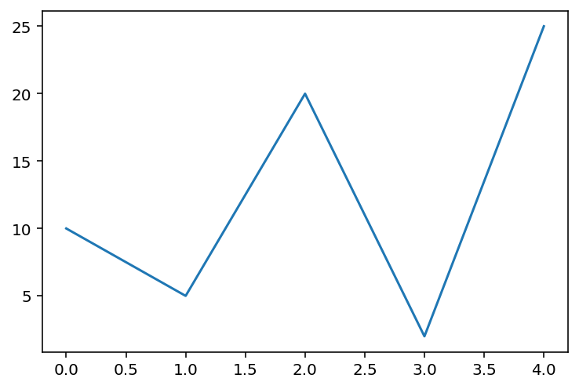

```python
plt.plot([10, 5, 20, 2, 25]);
```

`plot()` can also take two arguments: an iterable of $x$-coordinates and an iterable of $y$-coordinates:

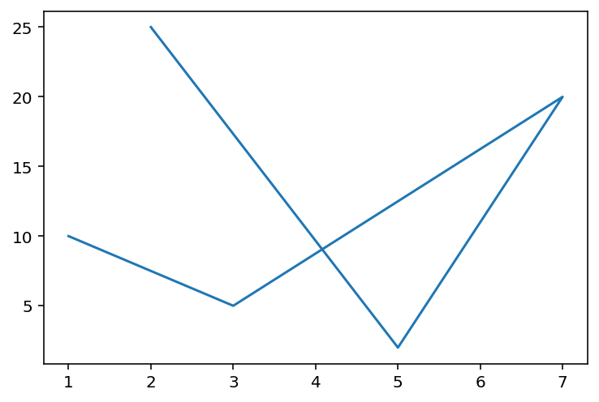

```python
plt.plot([1, 3, 7, 5, 2], [10, 5, 20, 2, 25]);
```

Usually, we rather have an iterable of pairs, one for each point to plot, the first and second components of the pair being the point's $x$- and $y$-coordinates, respectively. For instance, from the function $f:x\mapsto 2x$, we could generate the list of points `[(0, 0), (1, 2), (3, 6), (4, 8), (9, 18)]`; `plot()` should then be given `[0, 1, 3, 4, 9]` as first argument, and `[0, 2, 6, 8, 18]` as second argument (or any iterables representing the same sequences of data). The `zip()` function makes it easy to get the latter two sequences, as tuples, from the elements of the former list:

```python
list(zip((0, 0), (1, 2), (3, 6), (4, 8), (9, 18)))
```

```
[(0, 1, 3, 4, 9), (0, 2, 6, 8, 18)]
```

More generally, `zip()` accepts arbitrary iterables as arguments. The size of those iterables can differ: what is zipped is the iterables truncated if needed to the size of the shortest one:

```python
list(zip(range(1, 5), [11, 12, 13], [21, 22, 23, 24, 25], (31, 32, 33)))
```

```
[(1, 11, 21, 31), (2, 12, 22, 32), (3, 13, 23, 33)]
```

Observe that `zip()` is self-inverse, after some of the arguments have possibly been truncated to the size of the shortest one:

```python
list(zip(*zip((0, 0), (1, 2), (3, 6), (4, 8), (9, 18))))
list(zip(*zip(range(1, 5), [11, 12, 13], [21, 22, 23, 24, 25], (31, 32, 33))))
```

```
[(0, 0), (1, 2), (3, 6), (4, 8), (9, 18)]
```

```
[(1, 2, 3), (11, 12, 13), (21, 22, 23), (31, 32, 33)]
```

In applications where one needs to extend the iterables to the size of the longest sequence, then the `itertools` module comes to the rescue with `zip_longest()`, that has the `fillvalue` keyword-only parameter, with a default value of `None`:

```python
list(zip_longest([1], [11, 12], [21, 22, 23, 25], [31, 32]))
list(zip_longest([1], [11, 12], [21, 22, 23, 25], [31, 32], fillvalue=-1))
```

```
[(1, 11, 21, 31),
 (None, 12, 22, 32),
 (None, None, 23, None),
 (None, None, 25, None)]
```

```
[(1, 11, 21, 31), (-1, 12, 22, 32), (-1, -1, 23, -1), (-1, -1, 25, -1)]
```

Let us first examine the relative cost of creating, from a given collection, a list versus a set:

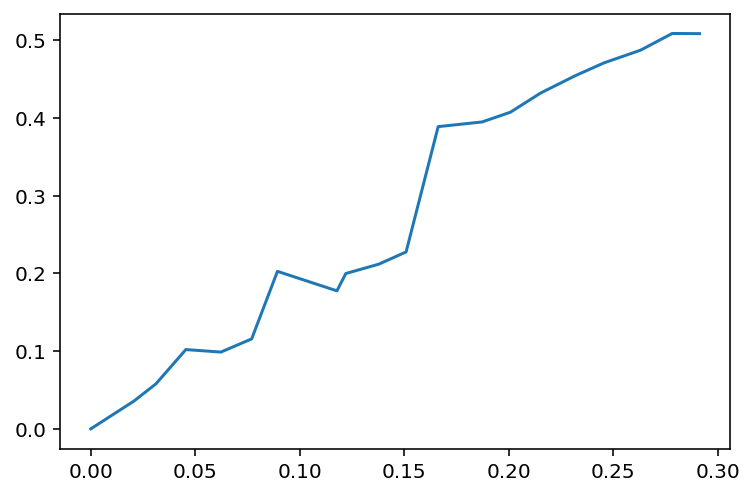

```python
data = []
for i in range(0, 10_000_000, 500_000):
    data.append((timeit(f'list(range({i}))', number=1),
                 timeit(f'set(range({i}))', number=1)
                )
               )
plt.plot(*zip(*data));
```

Creating these lists and sets takes time, all the more so that their size is larger. For a given large enough size, creating a set takes more time than creating a list. When estimating operations on lists or sets, we want to measure the time it takes to apply that operation to the list or set, without including the extra time needed to create them. When comparing the performance of a given operation on a list versus that same operation on a set, it is even more important not to take into account the time needed to create them, since as observed, that time differs. The `setup` argument of the `timeit()` function allows us to execute some statements prior to executing the statements whose running time we want to estimate.

Retrieving, in a list of size 10 million, the element whose index is a multiple of 500,000, does not significantly depend on the value of the index. As that operation is so efficient, we perform it 10 million times to make the evaluation more precise:

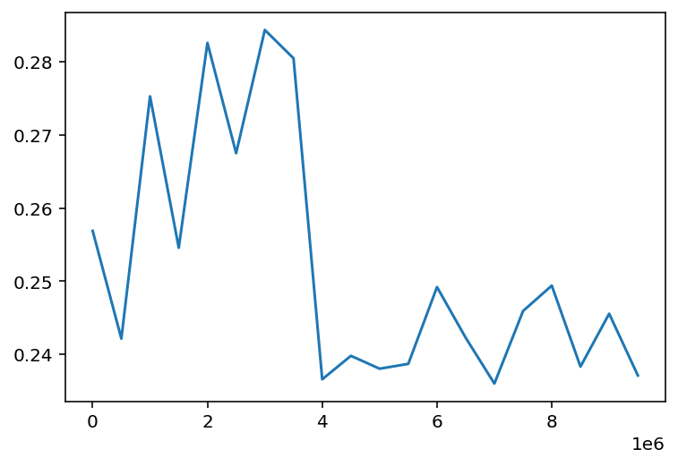

```python
data = []
for i in range(0, 10_000_000, 500_000):
    data.append((i, timeit(f'L[{i}]', setup='L = [None] * 10_000_000',
                           number=10_000_000
                          )
                )
               )
plt.plot(*zip(*data));
```

The next experiment consists in popping, in a list of size 10 thousand, the element whose index is a multiple of 500. The operation is performed 100,000 times, again to make the evaluation more precise, but the setup code is executed only once, so after each call to `pop()`, we append an element to the end of the list so as to maintain its size. The smaller the index is, that is, the closer the element being popped is to the beginning of the list, the larger is the number of elements that have to be "shifted" from right to left to fill the vacancy left by that element:

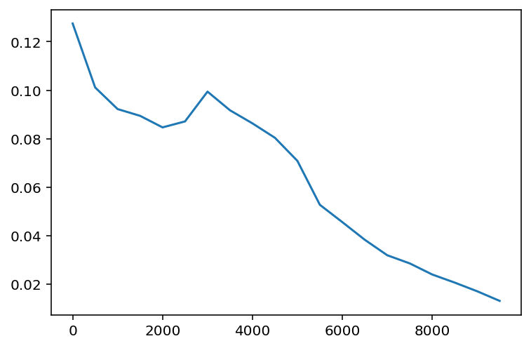

```python
data = []
for i in range(0, 10_000, 500):
    data.append((i, timeit(f'L.pop({i}); L.append(None)',
                           setup='L = [None] * 10_000', number=100_000
                          )
                )
               )
plt.plot(*zip(*data));
```

The next experiment consists in removing, in a list of size 14,500, an element (0), whose first occurrence has an index that is a multiple of 500, up to and including 9,500. The operation is performed 5,000 times, again to make the evaluation more precise; we again append an element to the end of the list so as to maintain its size. The cost of finding an element $e$ that is further and further away from the beginning of the list increases more than the cost of "shifting" fewer and fewer elements from right to left to fill the vacancy left by removing $e$ decreases:

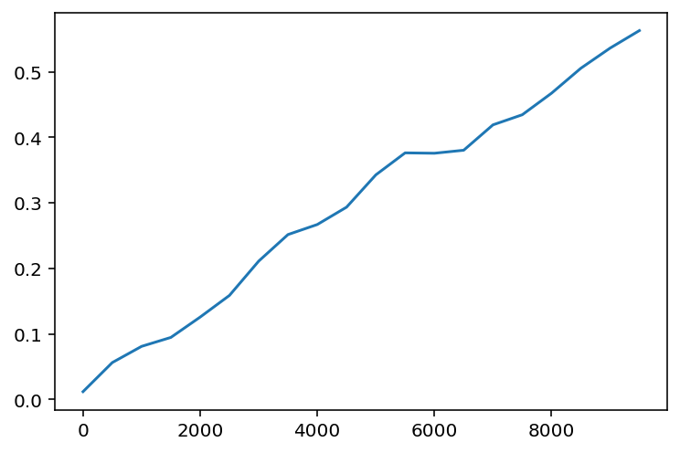

```python
data = []
for i in range(0, 10_000, 500):
    data.append((i, timeit('L.remove(0); L.append(None)',
                           setup=f'L = [None] * {i} + [0] * (14_500 - {i})',
                           number=5_000
                          )
                )
               )
plt.plot(*zip(*data));
```

The next experiment consists in removing, in the set of all numbers between 0 included and 10 thousand excluded, the multiples of 500. The operation is performed 20,000 times, again to make the evaluation more precise; right after we have removed an element from the set, we bring it back. The cost of removing an element from a set is independent of the value of that element:

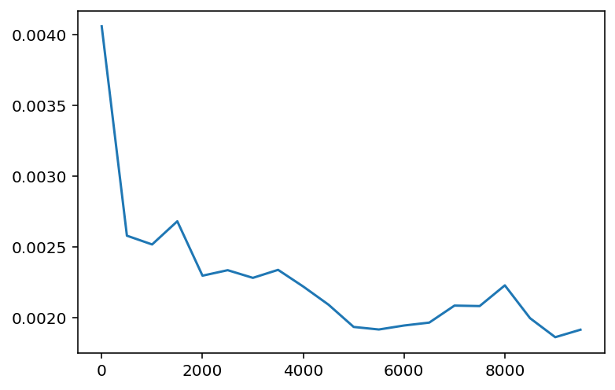

```python
data = []
for i in range(0, 10_000, 500):
    data.append((i, timeit(f'S.remove({i}); S.add({i})',
                           setup=f'S = set(range(10_000))',
                           number=20_000
                          )
                )
               )
plt.plot(*zip(*data));
```

It seems that the cost of removing an element from a set is not impressively less than the cost of removing the element in the middle of a list of the same size, but that is because removing and adding again and again the same element in a large set is an edge case of the underlying algorithm that implements the remove method of the set class. To better appreciate the efficiency of removing an element from a set, as opposed to removing an element from a list, we create a collection of all integers between 0 and an upper bound $n$, shuffle the collection, and remove 0, 1, 2, ... up to $n$ from it, so ending up with an empty collection. We see that we can make $n$ much larger when the collection is a set than when the collection is a list:

```python
timeit('for i in range(10_000): L.remove(E[i])',
       setup='from random import shuffle;'
              'L = list(range(10_000));'
              'E = list(range(10_000)); shuffle(E)',
       number=1
      )
```

```
0.22860373099683784
```

```python
timeit('for i in range(1_000_000): S.remove(E[i])',
       setup='from random import shuffle;'
              'S = set(range(1_000_000));'
              'E = list(range(1_000_000)); shuffle(E)',
       number=1
      )
```

```
0.38227019700570963
```

So though Euler's sieve sounded as a good idea and a possible improvement over Eratosthenes' sieve, it turned out to perform much worse because often applying the `remove()` method to a list is not efficient: it is on average linear in the length of the list. But applying the `remove()` method to a set is efficient: it has constant time complexity. This suggests to, at every stage when all proper multiples of a (prime) number have to be eliminated, get a set from the list of numbers that still remain, remove those multiples from the set, and then convert the resulting set back to a list. Sorting is costly, but being performed only as many times as there are prime numbers smaller than $\lfloor\sqrt n\rfloor$, it could still bring an improvement.

Also, that allows one to get back to the original idea of eliminating all proper multiples at most equal to $n$ of a given prime number $p$ that are not multiples of smaller prime numbers by multiplying $p$ with all numbers at least equal to $p$ in `sieve`, until the product exceeds $n$. The approach is flawed if numbers are eliminated from `sieve`, but it is valid if numbers are eliminated from a copy of `sieve` as a set. To demonstrate it, we define a new version of `eliminate_proper_multiples_from_set()` that makes use of a `global` **declaration**, a notion that we now introduce.

The value of a global variable can be accessed from within a function:

```python
a = 1

def f():
    print(a)

f()
a
```

```
1
```

```
1
```

A function can define a **local** variable with the same name as a global variable, the former then hiding the latter within the function:

```python
a = 1

def f():
    a = 2
    print(a)

f()
a
```

```
2
```

```
1
```

A function can change the value of a global variable. The global variable then has to be declared as `global` within the function:

```python
a = 1

def f():
    global a
    print(a)
    a = 2

f()
a
```

```
1
```

```
2
```

In the following code fragment, without a global declaration, the assignment of `2` to `a` makes `a` a local variable of the function `f()`. Within a function, a variable is either global (the `global` declaration being necessary if and only if the function has a statement that assigns some value to that variable) or local; it is not global in parts of the function, and local in other parts. And since one cannot get the value of a variable before that variable has been assigned a value, the definition of `f()` below is incorrect:

```python
a = 1

def f():
    print(a)
    a = 2

f()
```

```
---------------------------------------------------------------------------
UnboundLocalError                         Traceback (most recent call last)
/var/folders/22/1v351fd93qjf7j2gg8b7ztbh0000gn/T/ipykernel_86034/86659742.py in <module>
      5     a = 2
      6
----> 7 f()

/var/folders/22/1v351fd93qjf7j2gg8b7ztbh0000gn/T/ipykernel_86034/86659742.py in f()
      2
      3 def f():
----> 4     print(a)
      5     a = 2
      6

UnboundLocalError: local variable 'a' referenced before assignment
```

Now, to observe how, with `n` set to `25`, proper multiples of 2, proper multiples of 3 that are not multiples of 2, and proper multiples of 5, equal to $\lfloor\sqrt 25\rfloor$, that are multiples of neither 2 nor 3, are eliminated, we successively call the following function with `i` set to `0`, `1` and `2` as argument:

```python
def eliminate_proper_multiples_from_set(i):
    # We assume that this function will be called in the order
    #   eliminate_proper_multiples(0)
    #   eliminate_proper_multiples(1)
    #   eliminate_proper_multiples(2)
    #   ...
    global sieve
    sieve_as_set = set(sieve)
    print(f'Now eliminating proper multiples of {sieve[i]}')
    j = i
    while (factor := sieve[i] * sieve[j]) <= n:
            print(f' Eliminating {sieve[i]} * {sieve[j]} = {factor}')
            sieve_as_set.remove(factor)
            j += 1
    sieve = sorted(sieve_as_set)
```

```python
sieve = list(range(2, n + 1))
print_sieve_contents()
```

```
  2  3  4  5  6  7  8  9 10 11 12 13 14 15 16 17 18 19 20 21 22 23 24 25
```

```python
eliminate_proper_multiples_from_set(0)
print_sieve_contents()
```

```
Now eliminating proper multiples of 2
 Eliminating 2 * 2 = 4
 Eliminating 2 * 3 = 6
 Eliminating 2 * 4 = 8
 Eliminating 2 * 5 = 10
 Eliminating 2 * 6 = 12
 Eliminating 2 * 7 = 14
 Eliminating 2 * 8 = 16
 Eliminating 2 * 9 = 18
 Eliminating 2 * 10 = 20
 Eliminating 2 * 11 = 22
 Eliminating 2 * 12 = 24
  2  3  5  7  9 11 13 15 17 19 21 23 25
```

```python
eliminate_proper_multiples_from_set(1)
print_sieve_contents()
```

```
Now eliminating proper multiples of 3
 Eliminating 3 * 3 = 9
 Eliminating 3 * 5 = 15
 Eliminating 3 * 7 = 21
  2  3  5  7 11 13 17 19 23 25
```

```python
eliminate_proper_multiples_from_set(2)
print_sieve_contents()
```

```
Now eliminating proper multiples of 5
 Eliminating 5 * 5 = 25
  2  3  5  7 11 13 17 19 23
```

Putting it all together:

```python
def second_sieve_of_primes_up_to(n):
    sieve = list(range(2, n + 1))
    i = -1
    k = -1
    while k:
        k = 0
        i += 1
        sieve_as_set = set(sieve)
        while (factor := sieve[i] * sieve[i + k]) <= n:
            sieve_as_set.remove(factor)
            k += 1
        sieve = sorted(sieve_as_set)
    return sieve
```

```python
primes = second_sieve_of_primes_up_to(1_000)
nicely_display(primes, len(str(primes[-1])))
```

```
    2    3    5    7   11   13   17   19   23   29   31   37   41   43   47   53
   59   61   67   71   73   79   83   89   97  101  103  107  109  113  127  131
  137  139  149  151  157  163  167  173  179  181  191  193  197  199  211  223
  227  229  233  239  241  251  257  263  269  271  277  281  283  293  307  311
  313  317  331  337  347  349  353  359  367  373  379  383  389  397  401  409
  419  421  431  433  439  443  449  457  461  463  467  479  487  491  499  503
  509  521  523  541  547  557  563  569  571  577  587  593  599  601  607  613
  617  619  631  641  643  647  653  659  661  673  677  683  691  701  709  719
  727  733  739  743  751  757  761  769  773  787  797  809  811  821  823  827
  829  839  853  857  859  863  877  881  883  887  907  911  919  929  937  941
  947  953  967  971  977  983  991  997
```

This second version of Euler's sieve is indeed more efficient than the first version, but it is still less efficient than Eratosthenes' sieve:

```python
%timeit second_sieve_of_primes_up_to(500_000)
```

```
931 ms ± 70 ms per loop (mean ± std. dev. of 7 runs, 1 loop each)
```